# Market Sizing with Cluster Analysis

Alex Benecke

2025-07-10

## Project Approach

Market expansion involves many moving parts, including generating an analysis of the size of your new market. In order to prepare as a company, it is important to understand how likely a given product is to sell in new areas. This can be achieved by gaining insights into what factors may predict product sales in your current market, especially factors you can get about the new market you are entering.

In this analysis, I will use publicly available data to group market areas with similar demographic characteristics. Then, product sales will be compared between these groups to examine if meaningful differences exist. That is, **do existing market areas comprised of similar population demographics interact with the product in predictable ways?**

If market areas can be grouped in this way, we can examine demographics in the new market to see what group each best falls into. **Group behaviors can be used to estimate product sales in the new similar markets.** The advantage of this approach is that it relies only on publicly available data when moving into new areas.

In short, the aim of this analytical approach is to use what we do know (publicly-available data) to predict what we don’t know (what product sales might look like in a new market) by sorting similar markets into a finite set of groups.

## Project data

Demographic data will be gathered from the US Census. Company sales data will be represented by a Kaggle dataset on electric vehicles (EVs) available for Washington state. For this scenario, we will predict EV sales in Ohio (proposed new market).

First, the US Census data is accessed via API. For this analysis, Table DP03 *Selected Economic Characteristics* is used. Specifically, the API call grabs all data from DP03 from the 2023 5-year ACS estimates at the census tract level for every census tract in Washington (existing market) and Ohio (new market). Only percentage estimates will be retained.

Let’s take a look at what the initial data pull looks like after some quick manipulation to get each state-level dataset into a tidy format:

```r
setwd("/cloud/project/market_sizing_analysis")
library(tidyverse)
library(jsonlite)
library(cluster)
library(factoextra)
library(tigris)


# Get data ----------------------------------------------------------------

# Use API to retrieve: all of DP03 from US Census for Ohio
data <- fromJSON(url("https://api.census.gov/data/2023/acs/acs5/profile?get=group(DP03)&ucgid=pseudo(0400000US39$1400000)&descriptive=true"))
data <- as.data.frame(data)
colnames(data) <- data[1,]
data <- data[-1,]
data <- data %>%
  select(GEO_ID,NAME,ends_with("PE"))

metadata <- data[1,]
metadata <- metadata %>%
  pivot_longer(everything(),names_to="metric",values_to="description")
data <- data[-1,]

data2 <- fromJSON(url("https://api.census.gov/data/2023/acs/acs5/profile?get=group(DP03)&ucgid=pseudo(0400000US53$1400000)&descriptive=true"))
data2 <- as.data.frame(data2)
colnames(data2) <- data2[1,]
data2 <- data2[-1,]
data2 <- data2 %>%
  select(GEO_ID,NAME,ends_with("PE"))
data2 <- data2[-1,]

# Examine dataframe
str(data2)
```

```
## 'data.frame':    1784 obs. of  139 variables:
##  $ GEO_ID     : chr  "1400000US53001950100" "1400000US53001950200" "1400000US53001950301" "1400000US53001950302" ...
##  $ NAME       : chr  "Census Tract 9501; Adams County; Washington" "Census Tract 9502; Adams County; Washington" "Census Tract 9503.01; Adams County; Washington" "Census Tract 9503.02; Adams County; Washington" ...
##  $ DP03_0001PE: chr  "2119" "1494" "1198" "1847" ...
##  $ DP03_0002PE: chr  "52.9" "60.0" "55.9" "69.5" ...
##  $ DP03_0003PE: chr  "52.6" "60.0" "55.9" "69.5" ...
##  $ DP03_0004PE: chr  "51.3" "58.2" "54.7" "66.9" ...
##  $ DP03_0005PE: chr  "1.3" "1.8" "1.3" "2.6" ...
##  $ DP03_0006PE: chr  "0.2" "0.0" "0.0" "0.0" ...
##  $ DP03_0007PE: chr  "47.1" "40.0" "44.1" "30.5" ...
##  $ DP03_0008PE: chr  "1115" "896" "670" "1283" ...
##  $ DP03_0009PE: chr  "2.5" "3.0" "2.2" "3.7" ...
##  $ DP03_0010PE: chr  "1019" "691" "499" "798" ...
##  $ DP03_0011PE: chr  "51.3" "51.1" "39.3" "62.4" ...
##  $ DP03_0012PE: chr  "51.3" "51.1" "39.3" "62.4" ...
```

[output cut: 86 more lines]

There are a few notable issues to fix:

1. All data is currently of the type character (chr), so most variables should be converted to numeric.
2. Additionally, there are instances of a filler value (“-888888888”). These should be replaced with NA values.
3. Most cluster algorithms don’t deal well with missing data.

Resulting structure of the dataframe after cleaning up the first two issues:

```r
neg_to_na <- function(x) {
  ifelse(x<0,NA,x)
}

# convert to numeric & change negatives to NAs
data_clean <- data %>%
  union(data2) %>%
  mutate(across(c(DP03_0001PE:DP03_0137PE), as.numeric)) %>%
  mutate(across(c(DP03_0001PE:DP03_0137PE), neg_to_na))
nrow(data_clean)
```

```
## [1] 4952
```

Let’s deal with the 3rd data cleaning issue by looking at the number of NA values for each variable.

```r
# look at NAs
na_sums <- data_clean %>%
  summarise(across(everything(), ~ sum(is.na(.)))) %>%
  pivot_longer(everything(), names_to = "column", values_to = "na_count")

na_sums %>%
  arrange(desc(na_count)) %>%
  print(n=139)
```

```
## # A tibble: 139 × 2
##     column      na_count
##     <chr>          <int>
##   1 DP03_0025PE     4952
##   2 DP03_0062PE     4952
##   3 DP03_0063PE     4952
##   4 DP03_0065PE     4952
##   5 DP03_0067PE     4952
##   6 DP03_0069PE     4952
##   7 DP03_0071PE     4952
##   8 DP03_0073PE     4952
##   9 DP03_0086PE     4952
##  10 DP03_0087PE     4952
##  11 DP03_0088PE     4952
##  12 DP03_0090PE     4952
```

[output cut: 127 more lines]

We can remove variables with a large number of NAs. Then, we will scale the data to prepare for clustering.

```r
# remove variables with >40 NAs
vars_keep <- na_sums %>%
  filter(na_count<=40)
data_clean <- data_clean %>%
  select(vars_keep$column) %>%
  na.omit()
nrow(data_clean)
```

```
## [1] 4916
```

```r
# prep data for clustering
data_clust <- data_clean %>%
  mutate(across(where(is.numeric),
                ~ as.numeric(scale(.x))))
str(data_clean)
```

```
## 'data.frame':    4916 obs. of  103 variables:
##  $ GEO_ID     : chr  "1400000US39001770100" "1400000US39001770200" "1400000US39001770301" "1400000US39001770302" ...
##  $ NAME       : chr  "Census Tract 7701; Adams County; Ohio" "Census Tract 7702; Adams County; Ohio" "Census Tract 7703.01; Adams County; Ohio" "Census Tract 7703.02; Adams County; Ohio" ...
##  $ DP03_0001PE: num  3936 3753 2959 2938 3177 ...
##  $ DP03_0002PE: num  53.2 44.7 55.8 60.1 47.1 41.2 54.8 59.7 65.5 75.2 ...
##  $ DP03_0003PE: num  53.2 44.7 55.8 60.1 47.1 41.2 54.8 59.7 65.5 74.8 ...
##  $ DP03_0004PE: num  47.8 43.1 55.6 54.4 42.5 40.9 50.2 56.2 64.8 74.6 ...
##  $ DP03_0005PE: num  5.4 1.6 0.2 5.8 4.6 0.3 4.6 3.5 0.6 0.2 ...
##  $ DP03_0006PE: num  0 0 0 0 0 0 0 0 0 0.4 ...
##  $ DP03_0007PE: num  46.8 55.3 44.2 39.9 52.9 58.8 45.2 40.3 34.5 24.8 ...
##  $ DP03_0008PE: num  2093 1677 1651 1766 1496 ...
##  $ DP03_0009PE: num  10.1 3.6 0.4 9.6 9.8 0.8 8.3 5.8 1 0.3 ...
##  $ DP03_0010PE: num  2062 2017 1335 1574 1645 ...
##  $ DP03_0011PE: num  45.8 39.9 61 58.6 53.6 31.6 51.6 54.7 56.8 71.8 ...
##  $ DP03_0012PE: num  45.8 39.9 61 58.6 53.6 31.6 51.6 54.7 56.8 71.8 ...
```

[output cut: 88 more lines]

## K-means clustering

There are multiple ways to determine how many clusters to use for K-means cluster algorithms. One common way is to look at what is called an elbow plot, or plotting the Within-Cluster Sum of Squares (*WCSS*) for a range of possible number of clusters (*k*).

The optimal number of clusters is the point where increasing *k* provides less of a decrease in *WCSS*. Essentially, we are looking for the subjective point of diminishing returns.

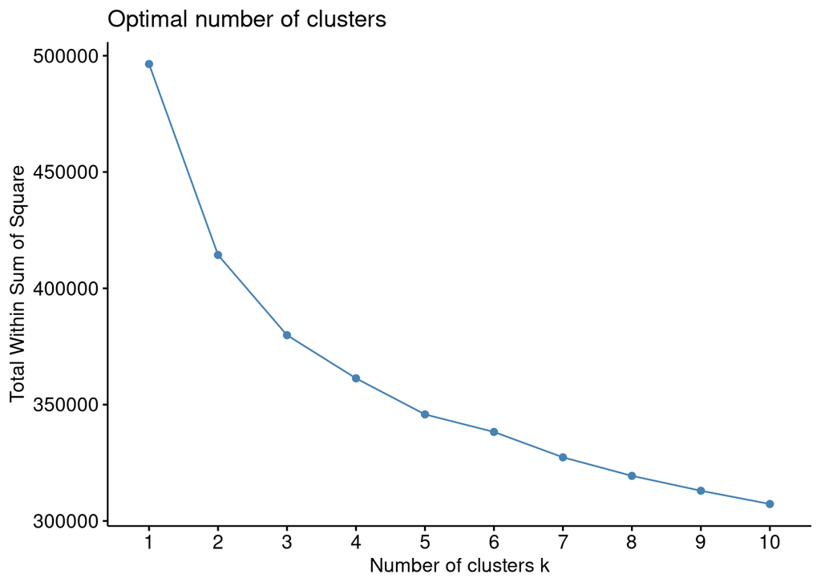

```r
# create plot of number of clusters vs total within sum of squares
fviz_nbclust(data_clust[3:103], kmeans, method = "wss")
```

It is not always a clear decision. In this case, let’s select 5 as the point of diminishing returns. Next, time to build the k-means model with *k*=5. The model will output a cluster assignment for each census tract (i.e. 1 through 5).

```r
# perform k-means clustering with k = 5 clusters
set.seed(17)
km <- kmeans(data_clust[3:103], centers = 5, nstart = 25)

# add cluster assignment to data
final_data <- cbind(data_clean, cluster = km$cluster)
```

## Examine Clusters

One downside to traditional k-means clustering is that we don’t know upfront how much each variable impacted the categorization. It can be helpful to examine cluster averages for the variables we used for the clustering to gain insight into what ways the cluster members are similar to one another and different from the other clusters.

First of all, let’s see how many census tracts ended up in each cluster:

```r
table(final_data$cluster)
```

```
##
##    1    2    3    4    5
##  668  525 1095 1542 1086
```

Next, let’s do an overview by each demographic variable:

### Cluster Summaries

Split across tabs to make visualization easier.

#### Variables 1:20

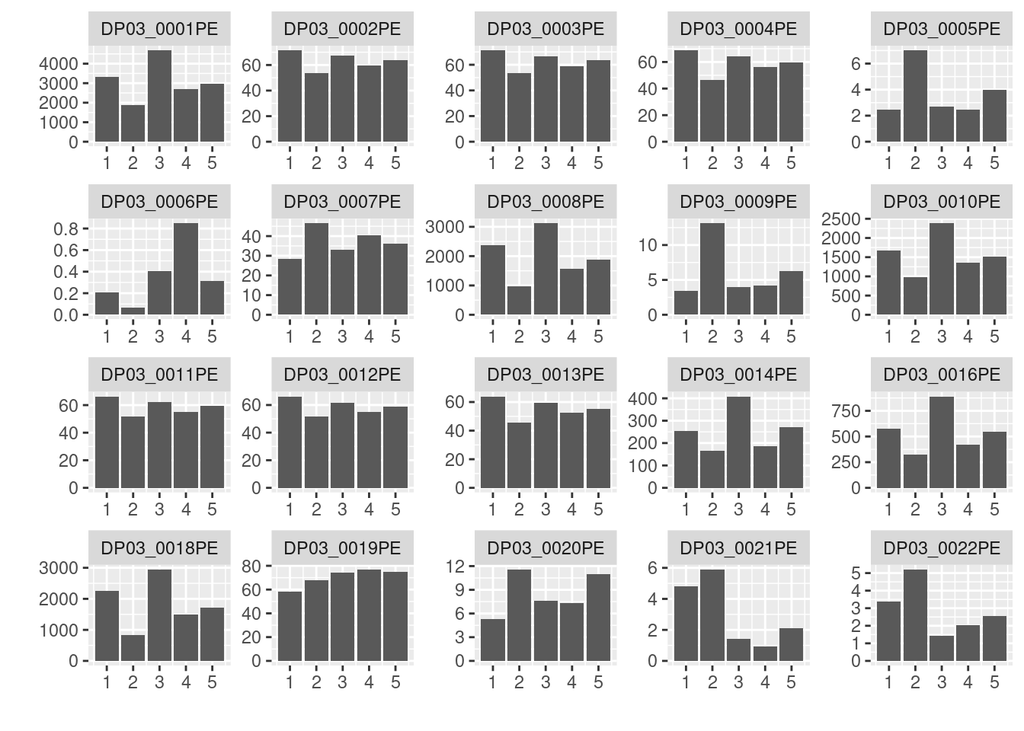

```r
ggplot(cluster_sums1,aes(x=cluster,y=value)) +
  geom_col() +
  facet_wrap(~metric,scales="free") +
  labs(x="",y="")
```

#### Variables 21:40

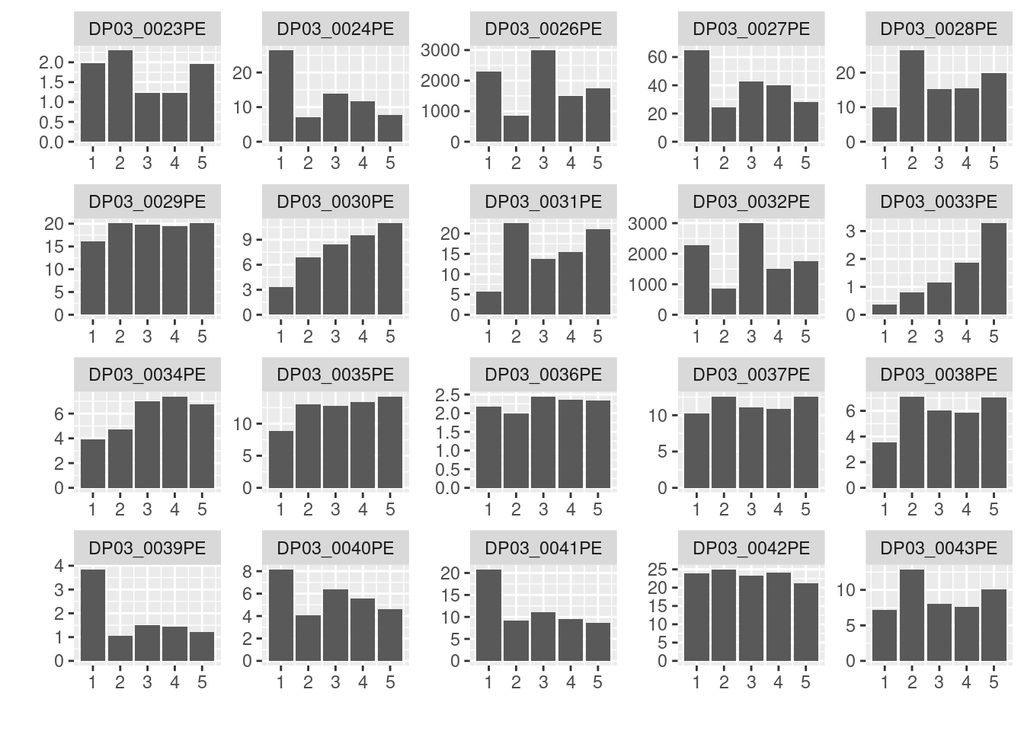

```r
ggplot(cluster_sums2,aes(x=cluster,y=value)) +
  geom_col() +
  facet_wrap(~metric,scales="free") +
  labs(x="",y="")
```

#### Variables 41:60

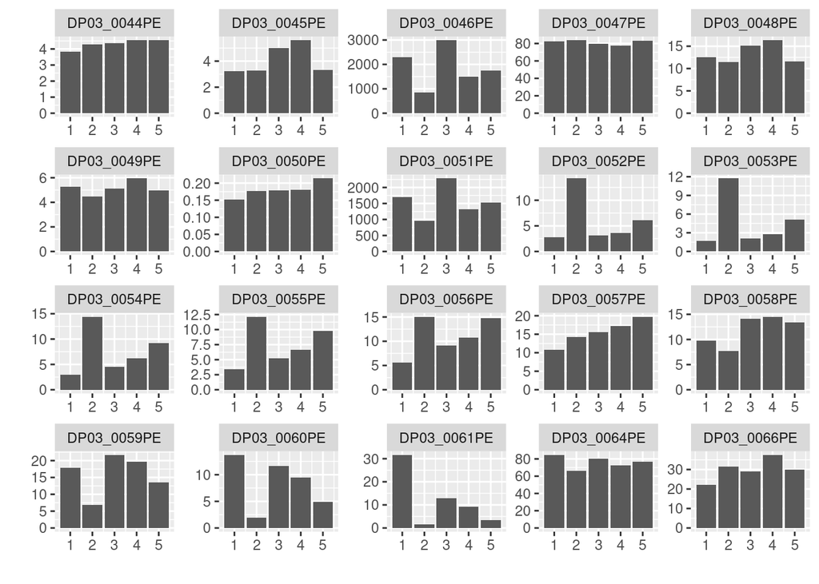

#### Variables 61:81

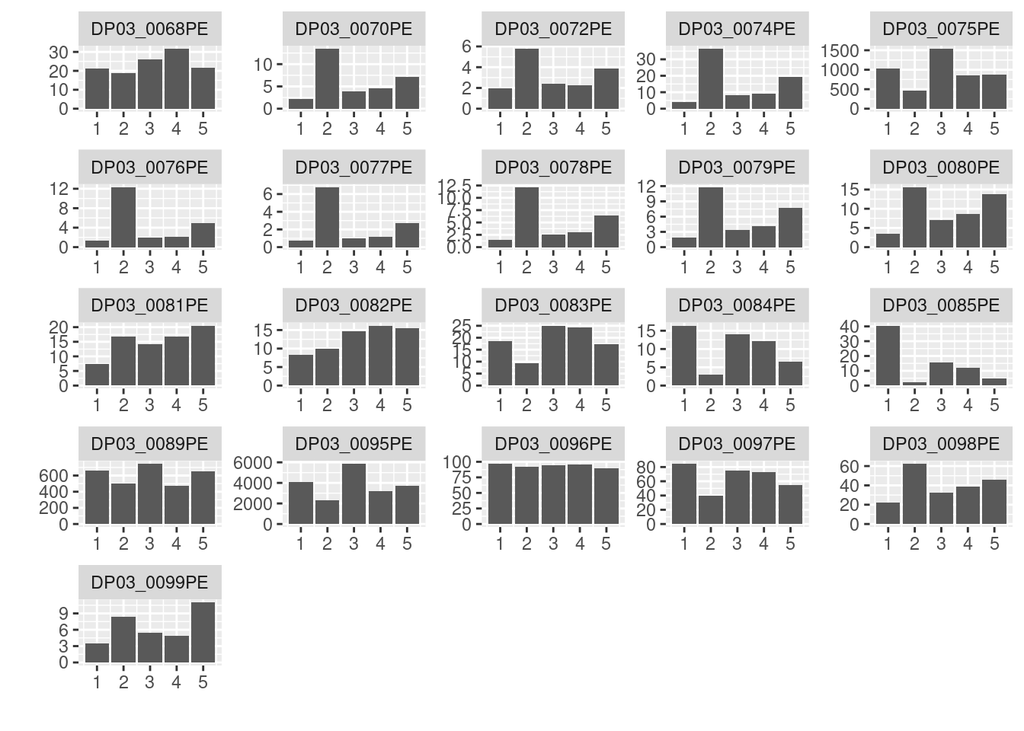

### Geography

Now, let’s get into the geography visualizations. How do these categorizations appear on maps of each market,?

```r
# Washington
wa_tracts <- tracts("WA")
wa_tracts <- final_data %>%
  select(GEO_ID,cluster) %>%
  right_join(wa_tracts,by=c("GEO_ID"="GEOIDFQ"))

table(wa_tracts$cluster,useNA="ifany")
```

```
##
##    1    2    3    4    5 <NA>
##  387   36  475  549  322   15
```

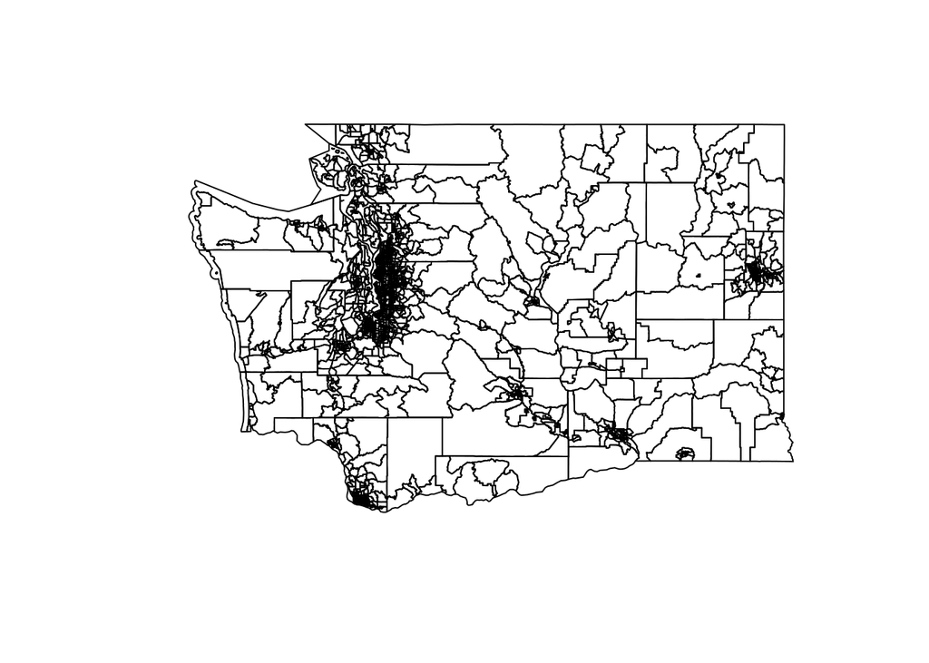

```r
plot(wa_tracts$geometry)
```

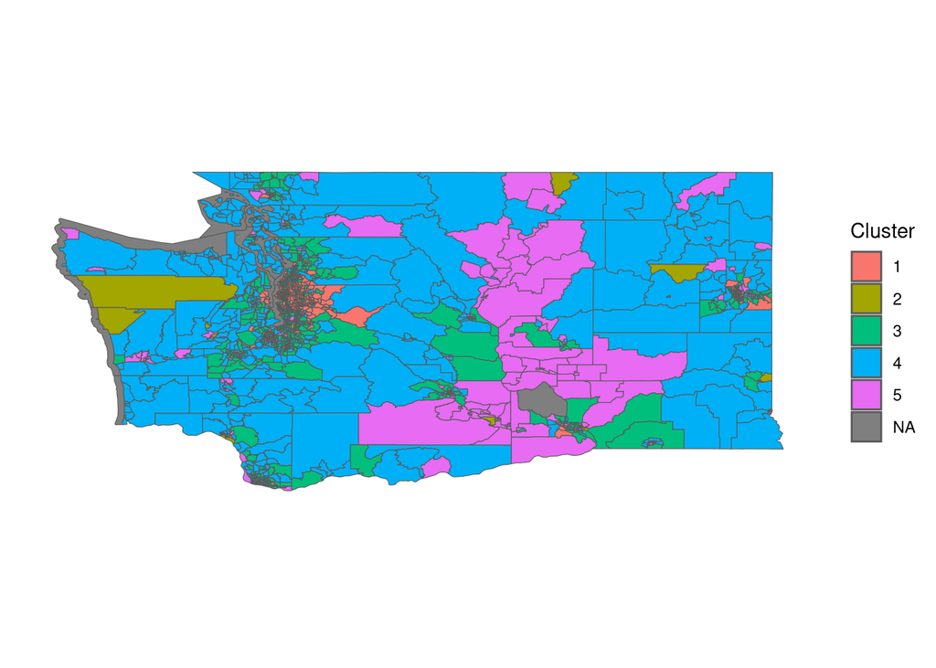

```r
ggplot() +
  geom_sf(data = wa_tracts, aes(fill = as.factor(cluster),geometry = geometry)) +
  labs(fill="Cluster") +
  theme(
    panel.background = element_blank(),
    axis.text = element_blank(),
    axis.title = element_blank(),
    axis.ticks = element_blank()
  )
```

```r
# Ohio
oh_tracts <- tracts("OH")
oh_tracts <- final_data %>%
  select(GEO_ID,cluster) %>%
  right_join(oh_tracts,by=c("GEO_ID"="GEOIDFQ"))

table(oh_tracts$cluster,useNA="ifany")
```

```
##
##    1    2    3    4    5 <NA>
##  281  489  620  993  764   21
```

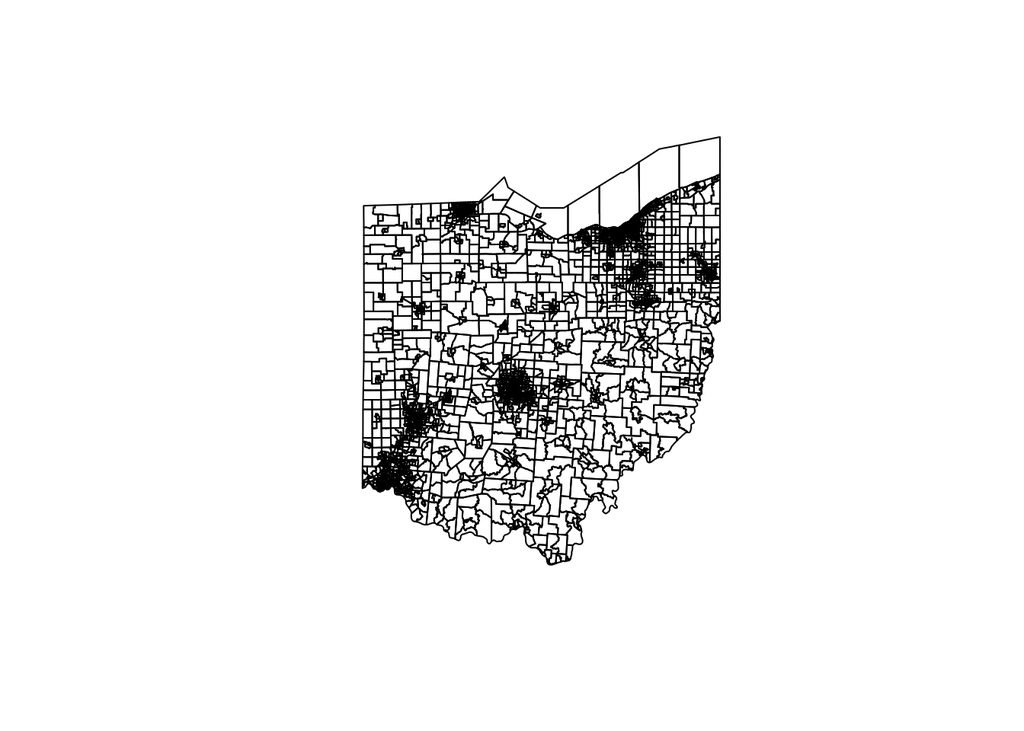

```r
plot(oh_tracts$geometry)
```

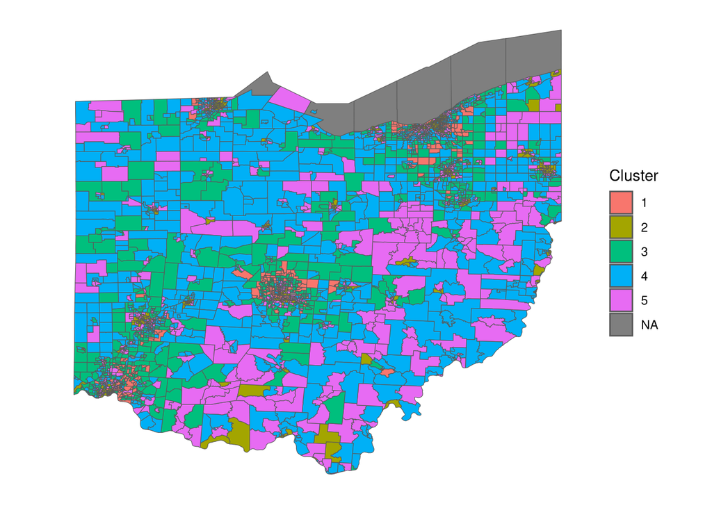

```r
ggplot() +
  geom_sf(data = oh_tracts, aes(fill = as.factor(cluster),geometry = geometry)) +
  labs(fill="Cluster") +
  theme(
    panel.background = element_blank(),
    axis.text = element_blank(),
    axis.title = element_blank(),
    axis.ticks = element_blank()
  )
```

## Bring in Product Data

Now that we have worked with the publicly-available Census data to create clusters of census tracts, it is time to test our hypothesis: **do existing market areas comprised of similar population demographics interact with the product in predictable ways?**